# Predicting Insurance Premiums

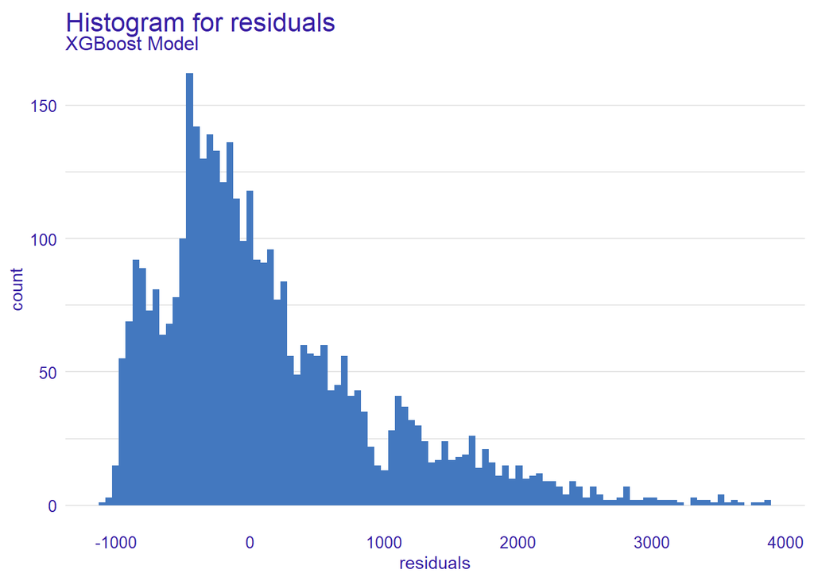

```r
plot(residuals, geom = "histogram")
```

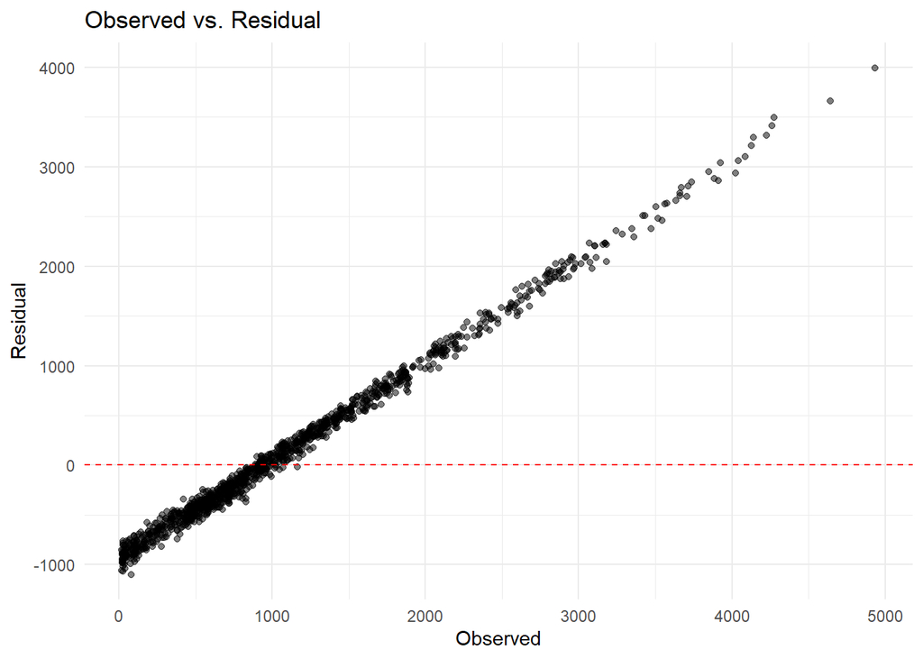

```r
test_predictions <- xgb_test_results %>%
  collect_predictions() %>%
  mutate(
    residual = premium_amount - .pred,
    abs_residual = abs(residual)
  )

test_predictions %>%
  ggplot(aes(x = premium_amount, y = residual)) +
  geom_point(alpha = 0.5) +
  geom_hline(yintercept = 0, color = "red", linetype = "dashed") +
  labs(
    x = "Observed",
    y = "Residual",
    title = "Observed vs. Residual"
  ) +
  theme_minimal()
```

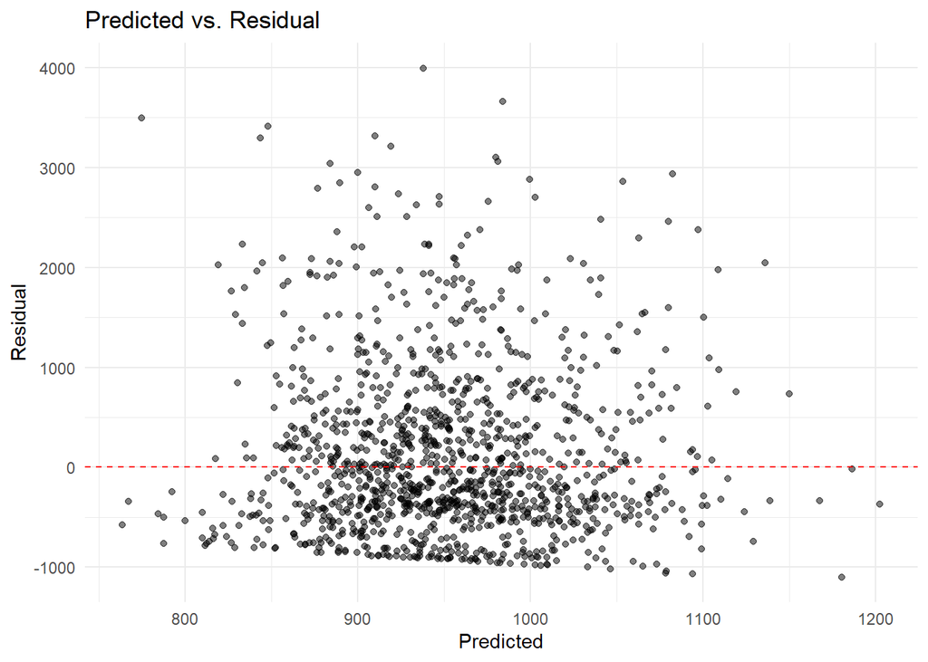

```r
test_predictions %>%
  ggplot(aes(x = .pred, y = residual)) +
  geom_point(alpha = 0.5) +
  geom_hline(yintercept = 0, color = "red", linetype = "dashed") +
  labs(x = "Predicted", y = "Residual",
       title = "Predicted vs. Residual") +
  theme_minimal()
```

## Comparison to Baseline Performance

Finally, I examined the MAE of a baseline model (i.e., predicting the mean) in order to better compare the final model.

```r
mean_prediction <- mean(test$premium_amount, na.rm = TRUE)

absolute_errors_mean <- abs(test$premium_amount - mean_prediction)

baseline_mean_mae <- mean(absolute_errors_mean)

baseline_mean_mae
```

```
[1] 655.1284
```

# Results and Discussion

In this project, three machine learning models were trained to predict `premium_amount`, a variable representing the insurance premiums that a given individual paid. The XGBoost model demonstrated that best predictive performance, achieving a Mean Absolute Error (MAE) of 634.38 on the testing data. While the XGBoost model was the best-performing of the three models, its R-squared value of .002 suggests that it explains only a small amount of variance more than a null model. Given that the MAE of a baseline model of predicting the mean of `premium_amount` in the testing data would be 655.13, the XGBoost model represents only a 3.16% improvement. Furthermore, an MAE of 634.38 indicates that, on average, the predictions made by the XGBoost model differed from the actual values of `premium_amount` by $634.38 dollars. As the mean of `premium_amount` in the test data was 1097.81, this represents a substantial average error.

Despite the poor performance of the model, permutation-based feature importance analysis provided some ideas as to what features did provide some predictive value. Specifically, this analysis revealed that the five most important variables were `annual_income`, `health_score`, `insurance_duration`, `credit_score`, and `age`.

Lastly, examining the residuals for the predictions of the XGBoost model provided some concrete direction as to what improvements need to be made to the model. Specifically, two things became apparent: (a) the range of predicted values was relatively constricted and (b) there were certain segments of observed values characterized by systematic under- and over-prediction. More in-depth feature engineering, full use of the dataset, and ensemble stacking might represent avenues for addressing these issues.